# Visualisation and analysis of mortality in Karnataka for 2018 and 2019

#### Importing necessary libraries

```python
import pandas as pd
from matplotlib import pyplot as plt
import geopandas as gpd
```

#### 'eight_death' and 'nine_death' contain the contribution of each cause of death for every district. With districts as the rows and causes as the columns.

#### The population used for the calculation of death rate is an estimate for 2020 created using the 2011 census.

```python
#Causes of deaths in 2018
eight_death = pd.read_csv(r"C:\Users\Anurag\Desktop\Karnataka\Varun Patil\cause_death_dist_2018.csv",encoding='latin-1')
#Causes of deaths in 2019
nine_death = pd.read_csv(r"C:\Users\Anurag\Desktop\Karnataka\Varun Patil\cause_death_dist_2019.csv",encoding='latin-1')
#List of cause names relating to the column names in the above files.
cause_list = pd.read_csv(r"C:\Users\Anurag\Desktop\Karnataka\Varun Patil\csss.csv",encoding='latin-1')
population2020 = pd.read_csv(r"C:\Users\Anurag\Desktop\Karnataka\Varun Patil\Population 2020.csv")
```

#### Using a downloaded shape file (.shp) to generate a map of Karnataka state

```python
eight_death.head()
```

|  | Year | Distict | Cause_1 | Cause_2 | Cause_3 | Cause_4 | Cause_5 | Cause_6 | Cause_7 | Cause_8 | ... | Cause_37 | Cause_38 | Cause_39 | Cause_40 | Cause_41 | Cause_42 | Cause_43 | Cause_44 | Cause_45 | Cause_46 |
| --- | --- | --- | --- | --- | --- | --- | --- | --- | --- | --- | --- | --- | --- | --- | --- | --- | --- | --- | --- | --- | --- |
| 0 | 2018 | Bagalkot | 19 | 14 | 8 | 15 | 18 | 10 | 18 | 15 | ... | 2 | 1250 | 32 | 18 | 5276 | 0 | 9 | 5 | 1 | 0 |
| 1 | 2018 | Ballari | 178 | 98 | 84 | 68 | 126 | 16 | 71 | 23 | ... | 1 | 1370 | 52 | 23 | 10790 | 0 | 127 | 80 | 7 | 0 |
| 2 | 2018 | Belagavi | 24 | 13 | 21 | 50 | 64 | 10 | 26 | 8 | ... | 7 | 2774 | 109 | 51 | 13162 | 0 | 49 | 26 | 1 | 0 |
| 3 | 2018 | Bengaluru | 108 | 30 | 51 | 64 | 434 | 42 | 59 | 22 | ... | 112 | 1636 | 422 | 287 | 8280 | 0 | 858 | 1602 | 55 | 0 |
| 4 | 2018 | Bengaluru Rural | 0 | 6 | 2 | 5 | 34 | 2 | 0 | 1 | ... | 39 | 490 | 64 | 4 | 614 | 0 | 15 | 6 | 3 | 0 |

5 rows × 48 columns

```python
cause_list.head()
```

|  | Cause ID | Cause |
| --- | --- | --- |
| 0 | 1 | Cholera |
| 1 | 2 | Typhoid |
| 2 | 3 | Food Poisoning |
| 3 | 4 | Dysentery & Gastroenterities |
| 4 | 5 | Tuberculosis |

```python
population2020.head()
```

|  | Distict | Population |
| --- | --- | --- |
| 0 | Bagalkot | 2141784 |
| 1 | Ballari | 3096512 |
| 2 | Belagavi | 5354714 |
| 3 | Bengaluru | 13626081 |
| 4 | Bengaluru Rural | 1139694 |

```python
map_d = gpd.read_file(r"C:\Users\Anurag\Downloads\gadm36_IND_shp\gadm36_IND_2.shp")
map_d = map_d[map_d["NAME_1"]=="Karnataka"].reset_index(drop=True)
map_d = map_d[["NAME_2","geometry"]]
```

```python
map_d.head()
```

|  | NAME_2 | geometry |
| --- | --- | --- |
| 0 | Bagalkot | POLYGON ((75.85240 15.93246, 75.84651 15.93122... |
| 1 | Bangalore | POLYGON ((77.75024 12.68716, 77.74709 12.68664... |
| 2 | Bangalore Rural | POLYGON ((77.75761 12.92880, 77.75718 12.93356... |
| 3 | Belgaum | POLYGON ((74.75089 15.49199, 74.74472 15.48939... |
| 4 | Bellary | POLYGON ((76.67507 14.89198, 76.67509 14.88698... |

#### Removing unnecessary columns from the data pertaining to both years

```python
eight_death.set_index("Distict", inplace=True)
eight_death.drop("Year",axis=1, inplace=True)
```

```python
nine_death.set_index("Distict", inplace=True)
nine_death.drop("Year",axis=1, inplace=True)
```

#### The names of district have changed throughout the years and so the shape files have a different name for the district than the mortality files. Hence the names have to be matched.

```python
old_names = ['Bagalkot', 'Bellary', 'Belgaum', 'Bangalore', 'Bangalore Rural',
       'Bidar', 'Chamrajnagar', 'Chikballapura', 'Chikmagalur',
       'Chitradurga', 'Dakshina Kannada', 'Davanagere', 'Dharwad',
       'Gadag', 'Hassan', 'Haveri', 'Gulbarga', 'Kodagu', 'Kolar',
       'Koppal', 'Mandya', 'Mysore', 'Raichur', 'Ramanagara', 'Shimoga',
       'Tumkur', 'Udupi', 'Uttara Kannada', 'Bijapur', 'Yadgir']

new_names = ['Bagalkot ', 'Ballari', 'Belagavi', 'Bengaluru', 'Bengaluru Rural',
       'Bidar', 'Chamarajanagar', 'Chikkaballapura', 'Chikkamagaluru',
       'Chitradurga', 'Dakshina Kannada', 'Davanagere', 'Dharwad', 'Gadag',
       'Hassan', 'Haveri', 'Kalaburagi', 'Kodagu', 'Kolar', 'Koppal', 'Mandya',
       'Mysuru', 'Raichur', 'Ramanagara', 'Shivamogga', 'Tumakuru', 'Udupi',
       'Uttara Kannada', 'Vijayapura', 'Yadgir']

map_d["NAME_2"].replace(old_names, new_names, inplace=True)
map_d.set_index("NAME_2", inplace=True)
```

#### Setting the district names as indexes so that the population data can be joined with the mortality data and map data in the following steps.

```python
population2020.set_index("Distict", inplace=True)
```

```python
merged_eight = map_d.join(eight_death)
merged_eight = merged_eight.join(population2020)
merged_eight['Total_deaths']= merged_eight.iloc[:,1:-1].sum(axis=1)
merged_eight["Death_rate"] = (merged_eight["Total_deaths"]*1000)/merged_eight["Population"]
```

```python
merged_nine = map_d.join(nine_death)
merged_nine = merged_nine.join(population2020)
merged_nine['Total_deaths']= merged_nine.iloc[:,1:-1].sum(axis=1)
merged_nine["Death_rate"] = (merged_nine["Total_deaths"]*1000)/merged_nine["Population"]
```

#### Plotting the total number of deaths in each district separately for the years 2018 and 2019.

It can be seen that Bengaluru has the highest number of deaths in both the years. This isn't surprising considering that it is a large city with a massive population.

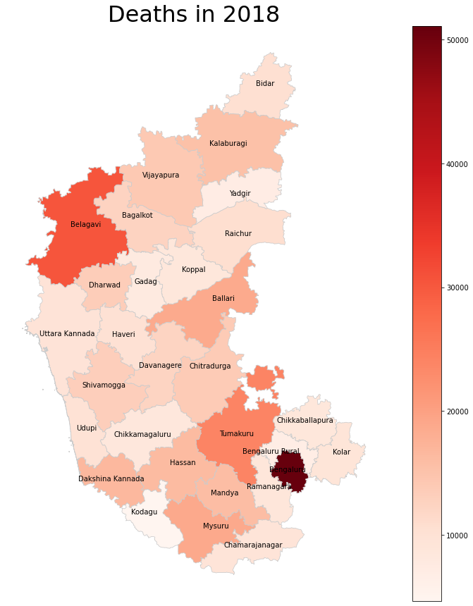

```python
vmin = merged_eight["Total_deaths"].min()
vmax = merged_eight["Total_deaths"].max()

fig, ax = plt.subplots(1, figsize=(15, 15))
sm = plt.cm.ScalarMappable(cmap="Reds", norm=plt.Normalize(vmin=vmin, vmax=vmax))
# empty array for the data range
sm._A = []
ax.axis("off")
ax.set_title("Deaths in 2018", fontdict={'fontsize': '32', 'fontweight' : '10'})
# add the colorbar to the figure
cbar = fig.colorbar(sm)
# create figure and axes for Matplotlib
merged_eight.plot(column="Total_deaths", cmap='Reds',ax=ax, linewidth=0.8, edgecolor='0.8');


# Add Labels
merged_eight['coords'] = merged_eight['geometry'].apply(lambda x: x.representative_point().coords[:])
merged_eight['coords'] = [coords[0] for coords in merged_eight['coords']]
for idx, row in merged_eight.iterrows():
    plt.annotate(s=idx, xy=row['coords'],horizontalalignment='center')

fig.savefig(r"C:\Users\Anurag\Desktop\Karnataka\Varun Patil\Output\total_deaths_2018.png", dpi=300)
```

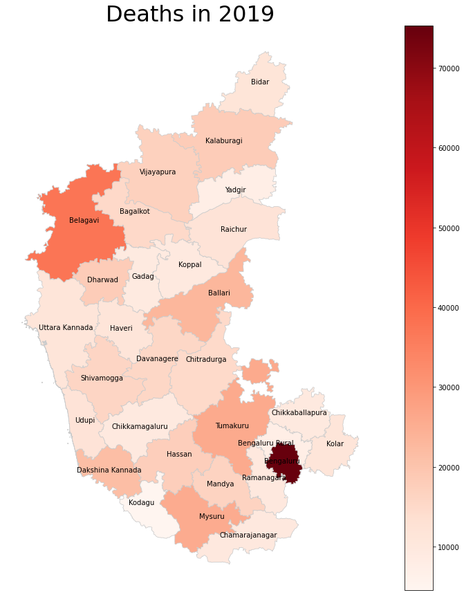

```python
vmin = merged_nine["Total_deaths"].min()
vmax = merged_nine["Total_deaths"].max()

fig, ax = plt.subplots(1, figsize=(15, 15))
sm = plt.cm.ScalarMappable(cmap="Reds", norm=plt.Normalize(vmin=vmin, vmax=vmax))
# empty array for the data range
sm._A = []
ax.axis("off")
ax.set_title("Deaths in 2019", fontdict={'fontsize': '32', 'fontweight' : '10'})
# add the colorbar to the figure
cbar = fig.colorbar(sm)
# create figure and axes for Matplotlib
merged_nine.plot(column="Total_deaths", cmap='Reds',ax=ax, linewidth=0.8, edgecolor='0.8');


# Add Labels
merged_nine['coords'] = merged_nine['geometry'].apply(lambda x: x.representative_point().coords[:])
merged_nine['coords'] = [coords[0] for coords in merged_nine['coords']]
for idx, row in merged_nine.iterrows():
    plt.annotate(s=idx, xy=row['coords'],horizontalalignment='center')

fig.savefig(r"C:\Users\Anurag\Desktop\Karnataka\Varun Patil\Output\total_deaths_2019.png", dpi=300)
```

#### Using the population per district estimate to calculate the death rate (which is the number of deats per 1000 people) in each district for years 2018 and 2019 separately. </br>

For 2018 Bengaluru(urban) has the lowest and Hassan has the highest death rate out of all districts. For 2019, Yadgir has the lowest death rate and Hassan has the highest. A possible reason for this could be population being registered in a different district as the death. In the case of Bangalore and Hassan, it is possible that a significant number of people got themselves registered in Bengaluru, but their deaths registered back in their native districts. This will cause the deaths in Bengaluru to be underestimated and the deaths in the neighbouring districts to be overestimated. Just as easily, this could be any abnormality resulting from the data also. Since the population that is considered here is not the actual population but the projected number from the 2011 census, whereas the deaths are records that are up to date for years 2018 and 2019. It is possible that the projection underestimated the urbanisation of Bengaluru and did not account for the people that moved to Bengaluru from other districts. It is inconclusive.

### Death rate plot 2018

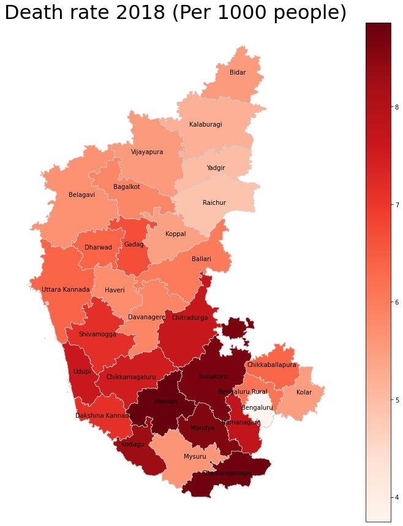

```python
vmin = merged_eight["Death_rate"].min()
vmax = merged_eight["Death_rate"].max()

fig, ax = plt.subplots(1, figsize=(15, 15))
sm = plt.cm.ScalarMappable(cmap="Reds", norm=plt.Normalize(vmin=vmin, vmax=vmax))
# empty array for the data range
sm._A = []
ax.axis("off")
ax.set_title("Death rate 2018 (Per 1000 people)", fontdict={'fontsize': '32', 'fontweight' : '10'})
# add the colorbar to the figure
cbar = fig.colorbar(sm)
# create figure and axes for Matplotlib
merged_eight.plot(column="Death_rate", cmap='Reds',ax=ax, linewidth=0.8, edgecolor='0.8');


# Add Labels
merged_eight['coords'] = merged_eight['geometry'].apply(lambda x: x.representative_point().coords[:])
merged_eight['coords'] = [coords[0] for coords in merged_eight['coords']]
for idx, row in merged_eight.iterrows():
    plt.annotate(s=idx, xy=row['coords'],horizontalalignment='center')

fig.savefig(r"C:\Users\Anurag\Desktop\Karnataka\Varun Patil\Output\death_rate_2018.png", dpi=300)
```

### Death rate plot 2019

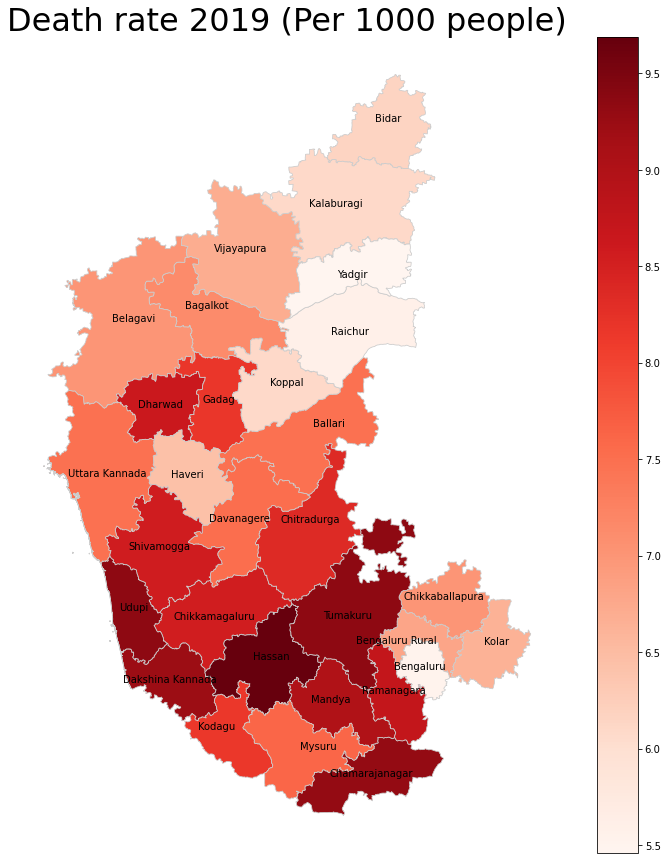

```python
vmin = merged_nine["Death_rate"].min()
vmax = merged_nine["Death_rate"].max()

fig, ax = plt.subplots(1, figsize=(15, 15))
sm = plt.cm.ScalarMappable(cmap="Reds", norm=plt.Normalize(vmin=vmin, vmax=vmax))
# empty array for the data range
sm._A = []
# add the colorbar to the figure
cbar = fig.colorbar(sm)
# create figure and axes for Matplotlib

ax.axis("off")
ax.set_title("Death rate 2019 (Per 1000 people)", fontdict={'fontsize': '32', 'fontweight' : '10'})
merged_nine.plot(column="Death_rate", cmap='Reds',ax=ax, linewidth=0.8, edgecolor='0.8');


# Add Labels
merged_nine['coords'] = merged_nine['geometry'].apply(lambda x: x.representative_point().coords[:])
merged_nine['coords'] = [coords[0] for coords in merged_nine['coords']]
for idx, row in merged_nine.iterrows():
    plt.annotate(s=idx, xy=row['coords'],horizontalalignment='center')
    #plt.annotate(s=idx, xy=row['coords'],horizontalalignment='center')

fig.savefig(r"C:\Users\Anurag\Desktop\Karnataka\Varun Patil\Output\death_rate_2019.png", dpi=300)
```

```python
#Saving death rates as csv
(merged_eight.reset_index()[["NAME_2","Death_rate"]]).to_csv(r"C:\Users\Anurag\Desktop\Karnataka\Varun Patil\Output\death_rate_eight.csv", index=False)
(merged_nine.reset_index()[["NAME_2","Death_rate"]]).to_csv(r"C:\Users\Anurag\Desktop\Karnataka\Varun Patil\Output\death_rate_nine.csv", index=False)
```

#### Visualising how the deaths in 2018 or 2018 death rate racks up with the 2019 death rate by plotting their ratio.

The ratio of death rate of 2019 to 2018 is visualised on the map below. The only district where the death rate reduced from 2018 to 2019 was Kodagu. In most other districts there was a significant increase in death rate. With a 47% increase, Bengaluru had the highest increase in death rate. Again, it can be noted that all the districts surrounding Bengaluru were amongst the districts that have the lowest increase in death rate. For some reason there was a tremendous increase in deaths from the year 2018 to 2019.

### Death rate ratio 2019 to 2018

```python
diff_eight_nine = pd.DataFrame(merged_nine["Death_rate"] / merged_eight["Death_rate"])
diff_eight_nine.set_index(merged_eight.index)

merged_diff = map_d.join(diff_eight_nine)
```

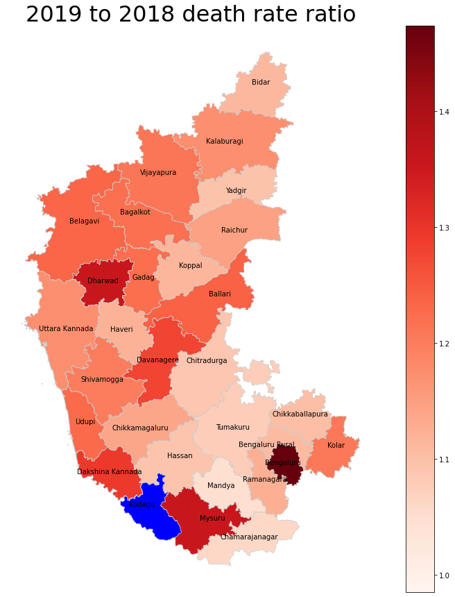

```python
# create figure and axes for Matplotlib
fig, ax = plt.subplots(1, figsize=(15,15))

vmin = merged_diff["Death_rate"].min()
vmax = merged_diff["Death_rate"].max()

sm = plt.cm.ScalarMappable(cmap="Reds", norm=plt.Normalize(vmin=vmin, vmax=vmax))
# empty array for the data range
sm._A = []
# add the colorbar to the figure
cbar = fig.colorbar(sm)

ax.axis("off")
ax.set_title("2019 to 2018 death rate ratio", fontdict={'fontsize': '32', 'fontweight' : '10'})

merged_diff.where(merged_diff.Death_rate>1).plot(column="Death_rate",vmax=vmax,vmin=vmin,cmap='Reds',ax=ax, linewidth=0.8, edgecolor='0.8');
merged_diff.where(merged_diff.Death_rate<=1).plot(color="b",ax=ax, linewidth=0.8, edgecolor='0.8');
#merged_diff.plot(column="Death_rate", cmap="bwr", ax=ax)

# Add Labels
merged_diff['coords'] = merged_diff['geometry'].apply(lambda x: x.representative_point().coords[:])
merged_diff['coords'] = [coords[0] for coords in merged_diff['coords']]
for idx, row in merged_diff.iterrows():
    plt.annotate(s=idx, xy=row['coords'],horizontalalignment='center')

fig.savefig(r"C:\Users\Anurag\Desktop\Karnataka\Varun Patil\Output\death_rate_ratio_19_18.png", dpi=300)
```

### Part two, diseases

```python
eight_death_one = eight_death.copy(deep=True)
nine_death_one = nine_death.copy(deep=True)

eight_death_one.columns = cause_list.Cause.values
nine_death_one.columns = cause_list.Cause.values
```

#### Using the seaborn library to plot heatmaps easily.

```python
import seaborn as sns
```

All the causes of death are plotted against all the districts for the year 2018 and 2019 separately. Also, for each year, a separate heatmap is plotted where the causes with very high number of associated deaths are omitted. The three omitted causes are: “Others not else where classified” , “Other Accidents” , “Not-Stated”.

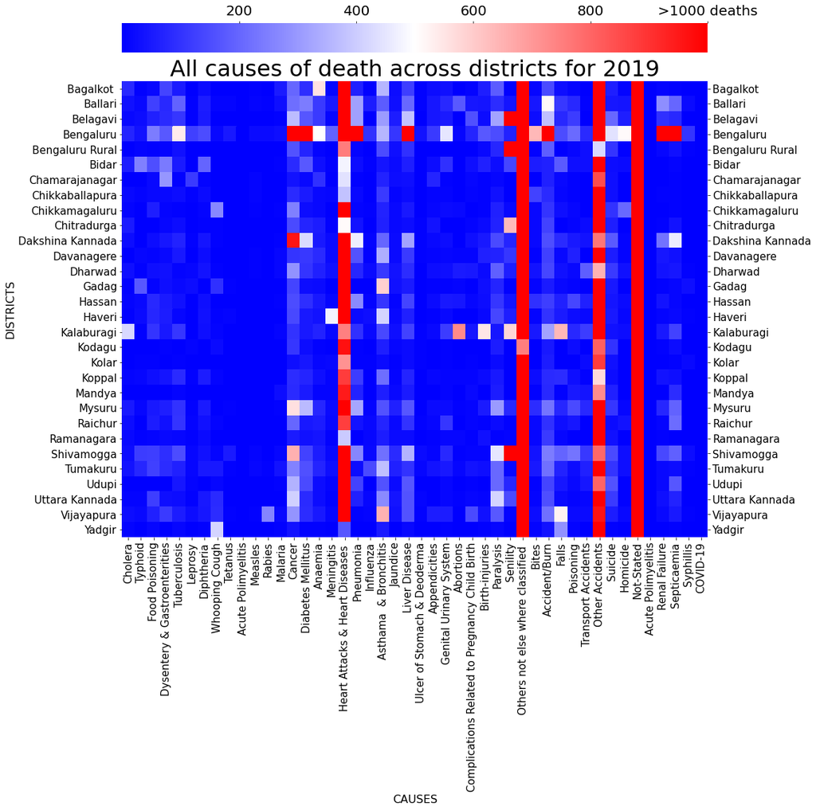

```python
fig, ax = plt.subplots(1, figsize=(15,15))
#ax.axis("off")
sb=sns.heatmap(nine_death_one,cmap="bwr",vmax=1000,cbar_kws=dict(ticks=[200,400,600,800,1000],location="top",use_gridspec=False))
ax.set_title("All causes of death across districts for 2019", fontdict={'fontsize': '32', 'fontweight' : '3'})
ax.tick_params(axis="x",labelsize=15,bottom=True, labelbottom=True)
ax.tick_params(axis="y",labelsize=15,right=True, labelright=True, rotation=0)
sb.set_xlabel("CAUSES",fontsize=16)
sb.set_ylabel("DISTRICTS",fontsize=16)
cbar = ax.collections[0].colorbar
cbar.ax.tick_params(labelsize=20)
cbar.set_ticklabels(['200', '400', '600', '800','>1000 deaths'])
fig.savefig(r"C:\Users\Anurag\Desktop\Karnataka\Varun Patil\Output\all_causes_19_heatmap.png", dpi=300, bbox_inches="tight")
```

### Without a few columns 2019

Some of these causes are omitted in the plot below. This is done beacuse these outliers skew the scale and make it hard to visualise the other important causes for mortality which are significant but lower in number.

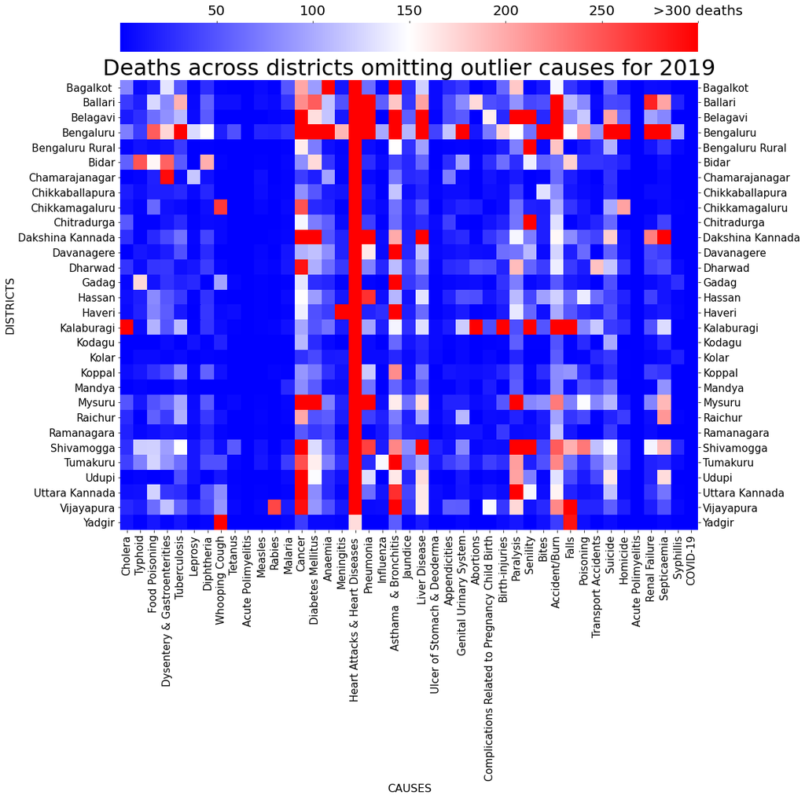

```python
fig, ax = plt.subplots(1, figsize=(15,15))
#ax.axis("off")
sb = sns.heatmap(nine_death_one.drop(['Others not else where classified ','Other Accidents','Not-Stated'],axis=1),cmap="bwr",vmax=300,cbar_kws={"ticks":[50,100,150,200,250,300],"location":"top","use_gridspec":False})
ax.set_title("Deaths across districts omitting outlier causes for 2019", fontdict={'fontsize': '32', 'fontweight' : '10'})

ax.tick_params(axis="x",labelsize=15,bottom=True, labelbottom=True)
ax.tick_params(axis="y",labelsize=15,right=True, labelright=True, rotation=0)
sb.set_xlabel("CAUSES",fontsize=16)
sb.set_ylabel("DISTRICTS",fontsize=16)
cbar = ax.collections[0].colorbar
cbar.set_ticklabels(['50', '100', '150', '200','250','>300 deaths'])
cbar.ax.tick_params(labelsize=20)
fig.savefig(r"C:\Users\Anurag\Desktop\Karnataka\Varun Patil\Output\without_few_causes_19_heatmap.png", dpi=300, bbox_inches="tight")
```

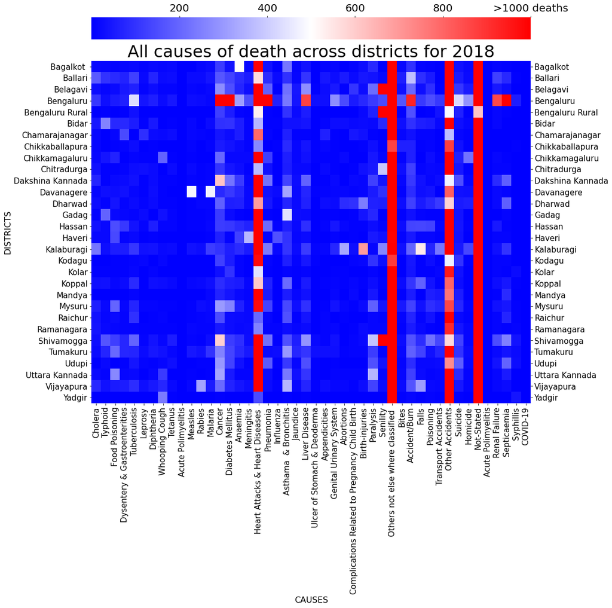

```python
fig, ax = plt.subplots(1, figsize=(15,15))
#ax.axis("off")
sb = sns.heatmap(eight_death_one,cmap="bwr",vmax=1000,cbar_kws={"ticks":[200,400,600,800,1000],"location":"top","use_gridspec":False})
ax.set_title("All causes of death across districts for 2018", fontdict={'fontsize': '32', 'fontweight' : '3'})

ax.tick_params(axis="x",labelsize=15,bottom=True, labelbottom=True)
ax.tick_params(axis="y",labelsize=15,right=True, labelright=True, rotation=0)
sb.set_xlabel( "CAUSES",fontsize=16)
sb.set_ylabel( "DISTRICTS",fontsize=16)
cbar = ax.collections[0].colorbar
cbar.set_ticklabels(['200', '400', '600', '800','>1000 deaths'])
cbar.ax.tick_params(labelsize=20)
fig.savefig(r"C:\Users\Anurag\Desktop\Karnataka\Varun Patil\Output\all_causes_18_heatmap.png", dpi=300, bbox_inches="tight")
```

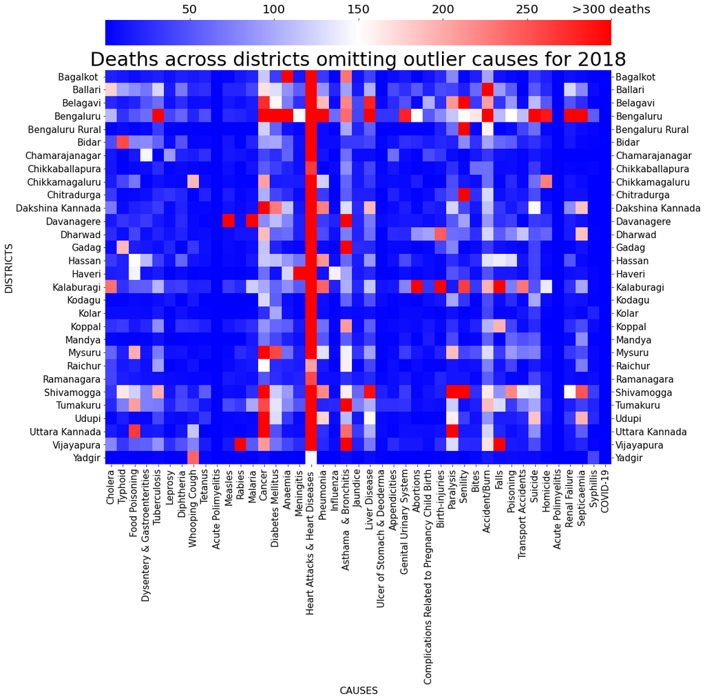

```python
fig, ax = plt.subplots(1, figsize=(15,15))
#ax.axis("off")
sb =sns.heatmap(eight_death_one.drop(['Others not else where classified ','Other Accidents','Not-Stated'],axis=1),cmap="bwr",vmax=300,cbar_kws={"ticks":[50,100,150,200,250,300],"location":"top","use_gridspec":False})

ax.tick_params(axis="x",labelsize=15,bottom=True, labelbottom=True)
ax.tick_params(axis="y",labelsize=15,right=True, labelright=True, rotation=0)
ax.set_title("Deaths across districts omitting outlier causes for 2018", fontdict={'fontsize': '32', 'fontweight' : '3'})
sb.set_xlabel("CAUSES",fontsize=16)
sb.set_ylabel("DISTRICTS",fontsize=16)
cbar = ax.collections[0].colorbar
cbar.set_ticklabels(['50', '100', '150', '200','250','>300 deaths'])
cbar.ax.tick_params(labelsize=20)
fig.savefig(r"C:\Users\Anurag\Desktop\Karnataka\Varun Patil\Output\without_few_causes_18_heatmap.png", dpi=300, bbox_inches="tight")
```

Some of the main causes of deaths in all cases are “Heart attacks and heart diseases”, ”Cancer”, “Asthama and Bronchitis”, “Diabetes Mellitus”, “Liver disease”, “Pneumonia” and “Accident/Burn”. Although the above four heatmaps highlight major causes of deaths, it fails to compare the causes between districts because of the varying population of districts. Meaning that district with more population naturally have a higher number of deaths due for each cause. Hence heatmaps are plotted using the death rates for each of the causes in each of the districts for the years 2018 and 2019 separately below.

### Sorted by population

This is done in order to visualise if there is a trend with respect to population. i.e. In order to check if more populated districts have causes that cause more deaths than distrcit that have lower population and vice-versa.

```python
eight_sorted_pop = eight_death_one.copy(deep=True)
eight_sorted_pop = eight_sorted_pop.join(population2020)
eight_sorted_pop.sort_values("Population", inplace=True)
```

```python
nine_sorted_pop = nine_death_one.copy(deep=True)
nine_sorted_pop = nine_sorted_pop.join(population2020)
nine_sorted_pop.sort_values("Population", inplace=True)
```

```python
for index in eight_sorted_pop.index:
    tempFrame = (eight_sorted_pop.loc[index] / eight_sorted_pop.loc[index]["Population"])*1000
    eight_sorted_pop.loc[index] = tempFrame.values

    tempFrame = (nine_sorted_pop.loc[index] / nine_sorted_pop.loc[index]["Population"])*1000
    nine_sorted_pop.loc[index] = tempFrame.values
```

#### Districts with higher population come lower in the heatmap. Bengaluru which has the highest population, comes last.

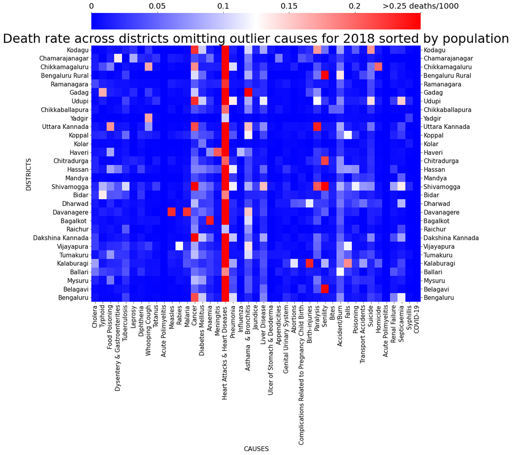

```python
fig, ax = plt.subplots(1, figsize=(15,15))
#ax.axis("off")

sb = sns.heatmap(eight_sorted_pop.drop(['Population','Others not else where classified ','Other Accidents','Not-Stated'],axis=1),cmap="bwr",vmax=0.25,cbar_kws={"ticks":[0,0.05,0.1,0.15,0.2,0.25],"location":"top","use_gridspec":False})

ax.tick_params(axis="x",labelsize=15,bottom=True, labelbottom=True)
ax.tick_params(axis="y",labelsize=15,right=True, labelright=True, rotation=0)
ax.set_title("Death rate across districts omitting outlier causes for 2018 sorted by population", fontdict={'fontsize': '32', 'fontweight' : '3'})
sb.set_xlabel("CAUSES",fontsize=16)
sb.set_ylabel("DISTRICTS",fontsize=16)
cbar = ax.collections[0].colorbar
cbar.set_ticklabels(["0","0.05","0.1","0.15","0.2",">0.25 deaths/1000"])
cbar.ax.tick_params(labelsize=20)
fig.savefig(r"C:\Users\Anurag\Desktop\Karnataka\Varun Patil\Output\without_few_causes_18_deathrate_heatmap.png", dpi=300, bbox_inches="tight")
```

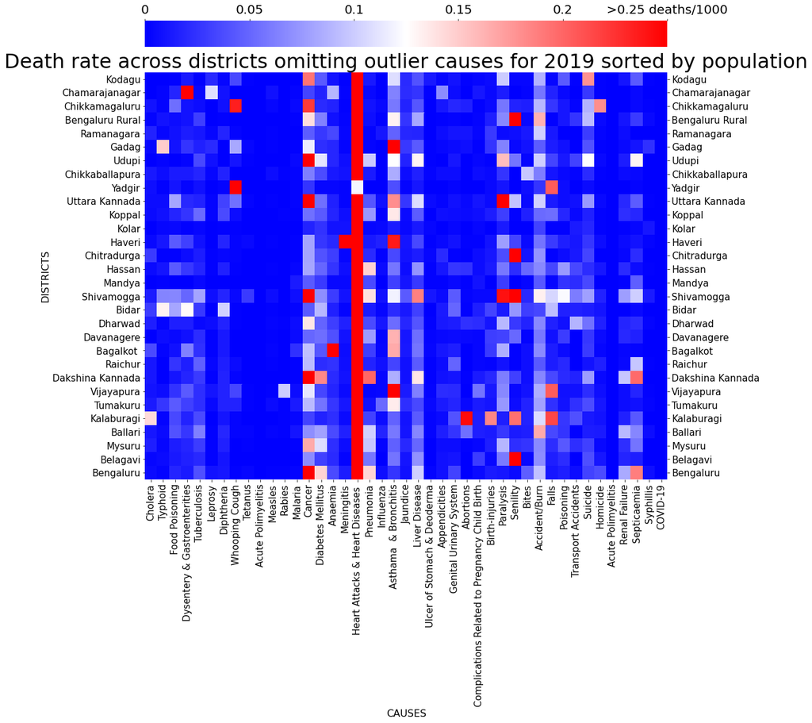

```python
fig, ax = plt.subplots(1, figsize=(15,15))
#ax.axis("off")

sb = sns.heatmap(nine_sorted_pop.drop(['Population','Others not else where classified ','Other Accidents','Not-Stated'],axis=1),cmap="bwr",vmax=0.25,cbar_kws={"ticks":[0,0.05,0.1,0.15,0.2,0.25],"location":"top","use_gridspec":False})

ax.tick_params(axis="x",labelsize=15,bottom=True, labelbottom=True)
ax.tick_params(axis="y",labelsize=15,right=True, labelright=True, rotation=0)
ax.set_title("Death rate across districts omitting outlier causes for 2019 sorted by population", fontdict={'fontsize': '32', 'fontweight' : '3'})
sb.set_xlabel("CAUSES",fontsize=16)
sb.set_ylabel("DISTRICTS",fontsize=16)
cbar = ax.collections[0].colorbar
cbar.set_ticklabels(["0","0.05","0.1","0.15","0.2",">0.25 deaths/1000"])
cbar.ax.tick_params(labelsize=20)
fig.savefig(r"C:\Users\Anurag\Desktop\Karnataka\Varun Patil\Output\without_few_causes_19_deathrate_heatmap.png", dpi=300, bbox_inches="tight")
```

#### Causes causing lot of deaths

Totalling the deaths caused by all causes and plotting them as a bar graph with a logarithmic y-axis. Other than miscellaneous causes, it can be seen that heart attack was the next major reason for deaths. The red bars show the magnitude of increase and the blue bars show the magnitude of decrease.

```python
total_deaths_per_disease = pd.concat([eight_death_one.sum(axis=0),nine_death_one.sum(axis=0)],axis=1)
total_deaths_per_disease.columns = ["2018","2019"]
total_deaths_per_disease["Total"] = total_deaths_per_disease["2018"] + total_deaths_per_disease["2019"]
total_deaths_per_disease.sort_values("Total",ascending=False,inplace=True)
total_deaths_per_disease["Difference"] = total_deaths_per_disease["2019"] - total_deaths_per_disease["2018"]
```

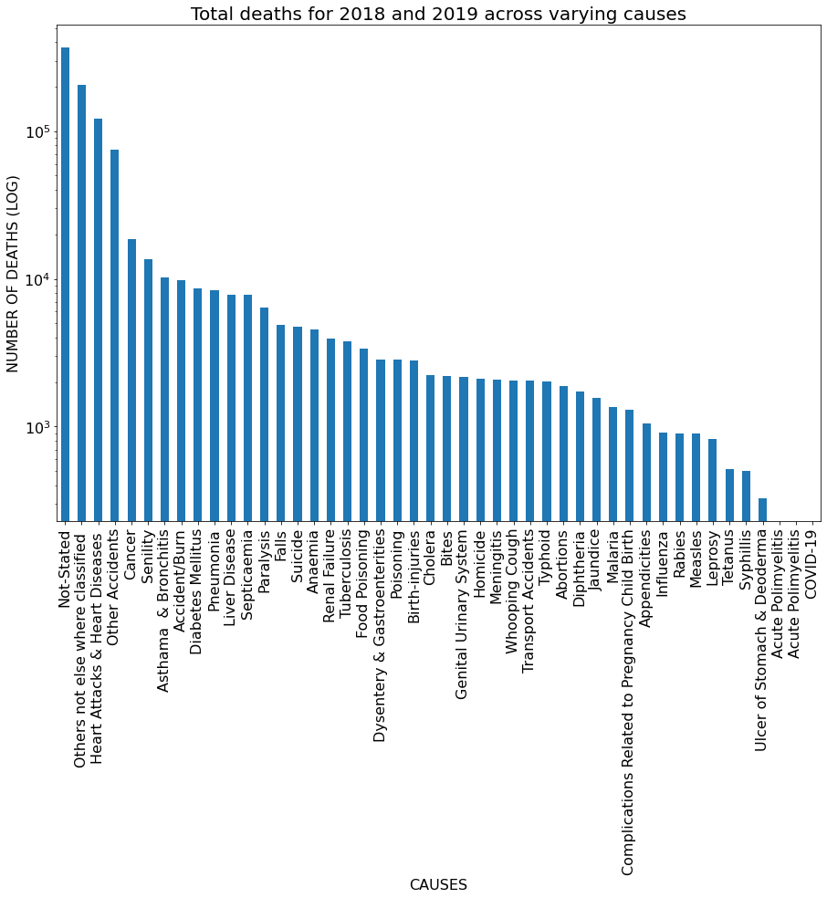

```python
g = total_deaths_per_disease["Total"].plot(kind='bar',title= "Total deaths for 2018 and 2019 across varying causes",fontsize=16, logy=True, figsize=(15,10))
g.title.set_size(20)
g.set_ylabel("NUMBER OF DEATHS (LOG)",fontsize=16)
g.set_xlabel("CAUSES",fontsize=16)
#bbox_inches="tight" below because while saving the image it cut out the axes labels
fig = g.get_figure()
fig.savefig(r"C:\Users\Anurag\Desktop\Karnataka\Varun Patil\Output\total_deaths.png", dpi=300, bbox_inches="tight")
```

#### Plotting the number of increase in the number of deaths from 2018 to 2019 for each cause

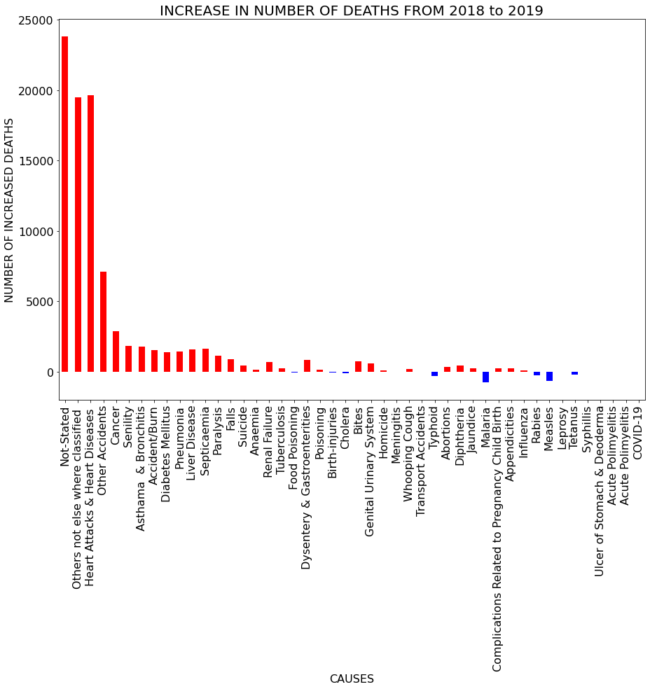

```python
g = total_deaths_per_disease.Difference.where(total_deaths_per_disease.Difference>0).plot(kind="bar",color="r",fontsize=16,figsize=(15,10))
total_deaths_per_disease.Difference.where(total_deaths_per_disease.Difference<0 ).plot(kind="bar",color="b", fontsize=16,figsize=(15,10), title="INCREASE IN NUMBER OF DEATHS FROM 2018 to 2019")
g.title.set_size(20)
g.set_ylabel("NUMBER OF INCREASED DEATHS",fontsize=16)
g.set_xlabel("CAUSES",fontsize=16)

fig = g.get_figure()
fig.savefig(r"C:\Users\Anurag\Desktop\Karnataka\Varun Patil\Output\deaths_difference_2018_2019.png", dpi=300, bbox_inches="tight")
```

```python
total_deaths_per_disease[["2018","2019","Total"]].to_csv(r"C:\Users\Anurag\Desktop\Karnataka\Varun Patil\Output\main_causes.csv")
```

```python
for index in eight_death_one.index:
    tempFrame = eight_death_one.loc[index].sort_values(ascending=False)
    eight_death_one.loc[index] = tempFrame.keys().values

    tempFrame = nine_death_one.loc[index].sort_values(ascending=False)
    nine_death_one.loc[index] = tempFrame.keys().values
```

```python
eight_death_one.to_csv(r"C:\Users\Anurag\Desktop\Karnataka\Varun Patil\Output\main_causes_2018.csv")
nine_death_one.to_csv(r"C:\Users\Anurag\Desktop\Karnataka\Varun Patil\Output\main_causes_2019.csv")
```